# Analysing John’s Data with our New Approach

Let’s try this out with john’s data at time point 18, and not perform the centering in advnace. Critcally, I’m going to use the raw counts from John’s Repo, and then perform the voom normalization myself, and use the weights from limma.I want to show that the weights a) don’t make a big difference, regardless of whether you use design matrix, and b) if we want to correct for RIN and extraction by using the voom object on the raw counts object and extracting the group wise coefficients from an `lmfit` that uses RIN and extr as additional covariates, we will lose $\mu_{j}$ unless we include an intercept term, but then we will have to add the intercept to our estimate $\chat_{jr}$

First, let’s generate the voom weights accoridng to John’s pipeline:

Preparing the data for modeling:

- Create the model using a treatment-contrast parametrization
- Normalize with TMM (`calcNormFactors`)
- Transform with `voom`
1. use full counts

```r
library("limma")
library("edgeR")
library('mash')
full <- read.table("counts_per_sample.txt", header = TRUE,
                   stringsAsFactors = FALSE)
full <- full[order(full$dir), ]
rownames(full) <- paste(full$dir, full$ind, full$bact, full$time, sep = ".")
counts <- t(full[, grep("ENSG", colnames(full))])
# Filter lowly expressed genes
counts <- counts[rowSums(cpm(counts) > 1) > 6, ]
dim(counts)
```

```
## [1] 12728   156
```

The first 9 columns are meta-data about each sample, and the remaining are the gene counts. Only the 12728 genes which have at least one read per million (pre-normalization with TMM) in at least six of the 156 samples are kept.

Prepare the factors for use in the linear model.

```r
groups <- full[, c("ind", "bact", "time", "extr", "rin")]
groups$bact <- gsub("\\+", "plus", groups$bact)
groups$ind <- factor(groups$ind)
groups$bact <- factor(groups$bact, levels = c("none", "Rv", "Rvplus", "GC",
                                              "BCG", "Smeg", "Yers", "Salm",
                                              "Staph"))
groups$time <- factor(groups$time, levels = c(4, 18, 48))
groups$extr <- factor(groups$extr)
head(groups)
```

```
##                 ind bact time extr rin
## 1.M372.none.4  M372 none    4    1 9.8
## 2.M375.Smeg.48 M375 Smeg   48    1 9.3
## 3.M373.GC.18   M373   GC   18    1 9.0
## 4.M374.BCG.48  M374  BCG   48    1 8.8
## 5.M375.none.4  M375 none    4    1 8.8
## 6.M372.Smeg.48 M372 Smeg   48    1 9.5
```

John’s model. Here we use the full experimental design matrix to generate the voom transformation object, and examine the weights. Note that he included individual, the interaction between bacteria and time, extraction and rin as covariates. I will really only be interested in time point 18 differences between bacteria, while I do want to control for extraction and rin.

```r
design <- model.matrix(~ ind + bact*time + extr + rin, data = groups)
# Clean up names of design matrix
colnames(design) <- gsub("ind", "", colnames(design))
colnames(design) <- gsub("time", "t", colnames(design))
colnames(design) <- gsub("bact", "", colnames(design))
colnames(design) <- gsub(":", ".", colnames(design))
colnames(design)[1] <- "Intercept"
# Remove Staph 48 hr timepoint that does not exist
design <- design[, -which(colnames(design) == "Staph.t48")]
print(colnames(design))
```

```
##  [1] "Intercept"  "M373"       "M374"       "M375"       "M376"
##  [6] "M377"       "Rv"         "Rvplus"     "GC"         "BCG"
## [11] "Smeg"       "Yers"       "Salm"       "Staph"      "t18"
## [16] "t48"        "extr2"      "extr3"      "extr4"      "extr5"
## [21] "extr6"      "extr7"      "extr8"      "extr9"      "extr10"
## [26] "extr11"     "extr12"     "extr13"     "rin"        "Rv.t18"
## [31] "Rvplus.t18" "GC.t18"     "BCG.t18"    "Smeg.t18"   "Yers.t18"
## [36] "Salm.t18"   "Staph.t18"  "Rv.t48"     "Rvplus.t48" "GC.t48"
## [41] "BCG.t48"    "Smeg.t48"   "Yers.t48"   "Salm.t48"
```

```r
y <- DGEList(counts)
y <- calcNormFactors(y)
v <- voom(y, design)
johnsweights=v$weights
head(johnsweights)[1:5,1:5]
```

```
##           [,1]      [,2]      [,3]      [,4]      [,5]
## [1,]  9.139349  8.797096 10.142211  6.615353  8.030769
## [2,]  3.284455  4.349423  3.856362  2.097220  2.528916
## [3,]  3.861901  4.528049  4.008811  3.727717  2.877673
## [4,] 11.569494 11.550720 11.469595 11.008874 11.498607
## [5,]  1.164309  4.803101  2.359421  6.824858  1.352667
```

My full model:

```r
model_mat <- model.matrix(~ bact + extr + rin- 1, data = groups)
# Clean up names of design matrix
colnames(model_mat) <- gsub("bact", "", colnames(model_mat))
colnames(model_mat) <- gsub(":", ".", colnames(model_mat))
#colnames(design)[1] <- "Intercept"
# Remove Staph 48 hr timepoint that does not exist
#design <- design[, -which(colnames(design) == "Staph.t48")]
print(colnames(model_mat))
```

```
##  [1] "none"   "Rv"     "Rvplus" "GC"     "BCG"    "Smeg"   "Yers"
##  [8] "Salm"   "Staph"  "extr2"  "extr3"  "extr4"  "extr5"  "extr6"
## [15] "extr7"  "extr8"  "extr9"  "extr10" "extr11" "extr12" "extr13"
## [22] "rin"
```

```r
###now just do for time point 18
knownsamples=which(groups$time==18&groups$bact!="none")
model_mat <- model_mat[knownsamples,-which(colnames(model_mat) == "none")]##remove the none column
dim(model_mat)
```

```
## [1] 48 21
```

```r
colnames(model_mat)
```

```
##  [1] "Rv"     "Rvplus" "GC"     "BCG"    "Smeg"   "Yers"   "Salm"
##  [8] "Staph"  "extr2"  "extr3"  "extr4"  "extr5"  "extr6"  "extr7"
## [15] "extr8"  "extr9"  "extr10" "extr11" "extr12" "extr13" "rin"
```

Now, I will generate a voom object using the rawcounts for the time point 18 individuals and the full model matrix (that does not include individual or time point bacteria interactions:

```r
vsarah <- voom(y[,knownsamples], model_mat)
sarahsweights=vsarah$weights
head(sarahsweights)[1:5,1:5]
```

```
##           [,1]      [,2]      [,3]      [,4]      [,5]
## [1,] 12.181873 10.368416 13.058607 13.275379 12.241563
## [2,]  5.188423  5.402414  8.668110  6.877942  6.358825
## [3,]  4.707930  3.622067  6.068662  6.019590  4.739877
## [4,] 13.073372 13.502683 12.509873 12.393950 11.988807
## [5,]  4.111064  2.617908  4.481665  4.727711  2.495473
```

```r
##show how many individuals in each class##
colSums(model_mat)[c(1:8)]
```

```
##     Rv Rvplus     GC    BCG   Smeg   Yers   Salm  Staph
##      6      6      6      6      6      6      6      6
```

```r
beta_class <- matrix(0, dim(counts)[1], 8);
sebeta_class <- matrix(0, dim(counts)[1], 8)
t_class = matrix(0, dim(counts)[1], 8)

colnames(counts[,knownsamples])[10]
```

```
## [1] "32.M377.Smeg.18"
```

```r
which(model_mat[10,]==1)
```

```
##  Smeg extr3
##     5    10
```

Now for each bacteria, we will fit the model including that bacteria and the rin/extraction covariates and extract the covariate for the bacteria only. We can compare using different types of weights, and to using the log2cpm batch/extraction normalized data. Let’s just test for the first bacteria type Rv.

Ideally, the voom object weights should be generated with the same model matrix used to extract covariates of interest (see Limma manual).

```r
k=1
batchcorrectedcpm=read.table("~/Dropbox/oldnobaseline/john/s1table.txt",header = T)[,-c(1,2)]

#for(k in c(1:8)){

model_mat_temp <- cbind(model_mat[,c(k,c(9:21))]);
  vsarah <- voom(y[,knownsamples], model_mat_temp)##here with partial model fit
  vsarah2 <- voom(y[,knownsamples], model_mat)##here with full model
  vnodesign <- voom(y[,knownsamples])
  limma.obj <- limma::lmFit(vsarah$E, model_mat_temp,weights=vsarah$weights);
  limma.obj2 <- limma::lmFit(vsarah$E, model_mat_temp,weights=vsarah2$weights);
  limma.obj3 <- limma::lmFit(vsarah$E, model_mat_temp,weights=johnsweights[,knownsamples]);
  limma.obj4 <- limma::lmFit(vsarah$E, model_mat_temp,weights=vnodesign$weights);
  l=lmFit(object = batchcorrectedcpm[,knownsamples],model_mat_temp[,1],weights=vsarah$weights[,1])
  lnodesign=lmFit(object = batchcorrectedcpm[,knownsamples],model_mat_temp[,1],weights=vnodesign$weights)
  lnoweights=lmFit(object = batchcorrectedcpm[,knownsamples],model_mat_temp[,1])
  #beta_class[,k] <- as.matrix(limma.obj$coefficients[,1]);
  #sebeta_class[,k] <- limma.obj$sigma*(as.matrix(limma.obj$stdev.unscaled[,1]));
  #t_class[,k] = (as.matrix(limma.obj$coefficients[,1]))/(limma.obj$sigma*(as.matrix(limma.obj$stdev.unscaled[#,7])));
  #}

head(limma.obj$coefficients[,1])
```

```
## ENSG00000000419 ENSG00000000457 ENSG00000000460 ENSG00000000938
##      0.01109801     -0.14489405      0.02185135      0.32655434
## ENSG00000000971 ENSG00000001036
##     -0.73364199     -0.00207075
```

```r
head(limma.obj2$coefficients[,1])
```

```
## ENSG00000000419 ENSG00000000457 ENSG00000000460 ENSG00000000938
##     -0.01627285     -0.07364053      0.01464128      0.27726683
## ENSG00000000971 ENSG00000001036
##     -0.56205011     -0.07161047
```

```r
head(limma.obj3$coefficients[,1])
```

```
## ENSG00000000419 ENSG00000000457 ENSG00000000460 ENSG00000000938
##     -0.01337946     -0.06573154      0.02199920      0.27394256
## ENSG00000000971 ENSG00000001036
##     -0.67156429     -0.06922722
```

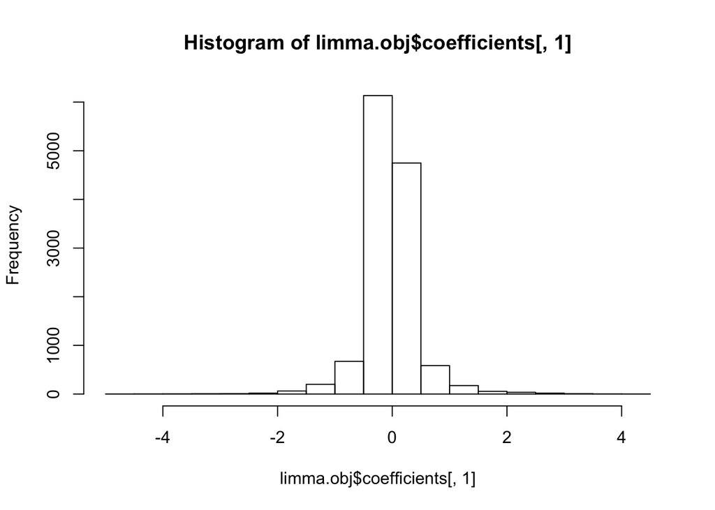

```r
hist(limma.obj$coefficients[,1])
```

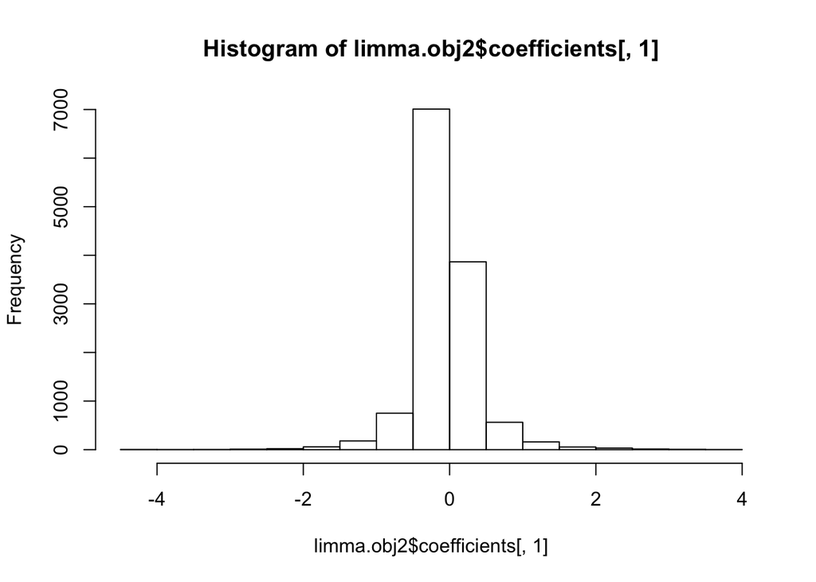

```r
hist(limma.obj2$coefficients[,1])
```

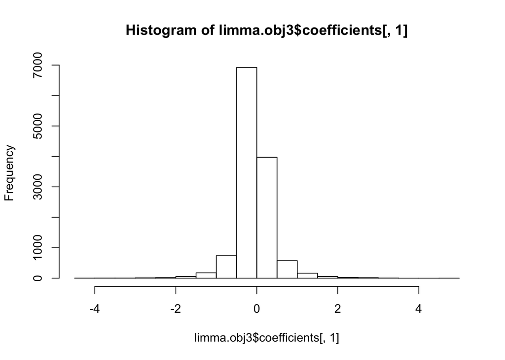

```r
hist(limma.obj3$coefficients[,1])
```

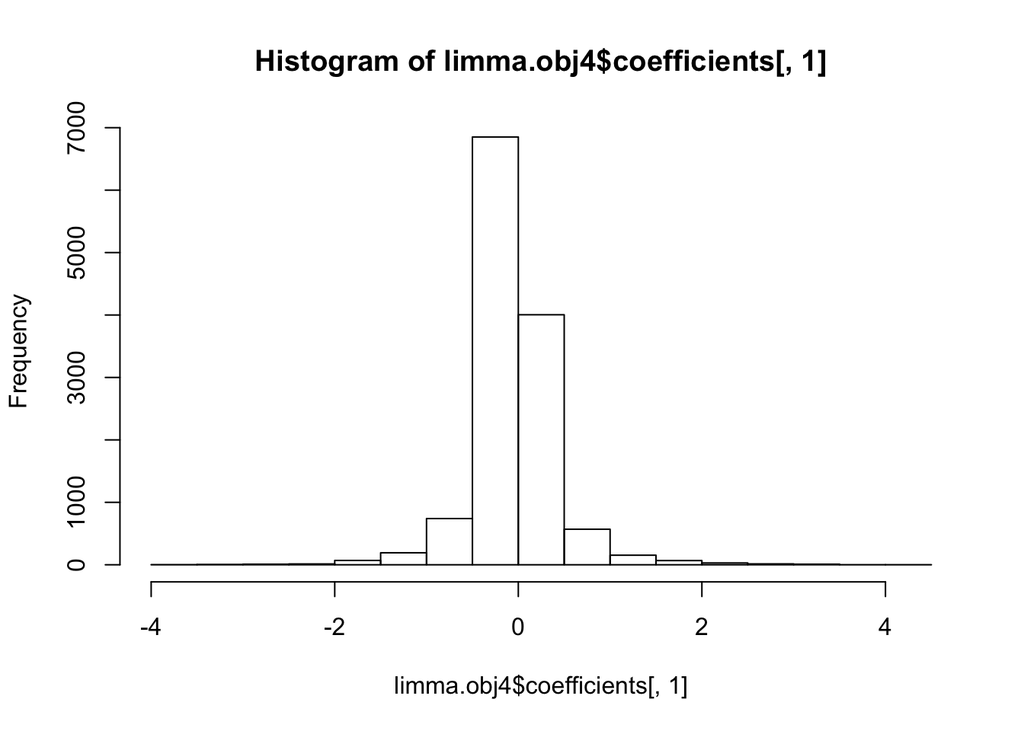

```r
hist(limma.obj4$coefficients[,1])
```

And here are the summaries of the average log2cpm (adjusted for batch and RIN) where we fit only one covariate (group status) using different itereations of weights:

```r
head(l$coefficients[,1])
```

```
## [1] 4.843589 1.519525 2.467317 7.356836 1.901124 7.088036
```

```r
head(lnoweights$coefficients[,1])
```

```
## [1] 4.843589 1.519525 2.467317 7.356836 1.901124 7.088036
```

```r
head(lnodesign$coefficients[,1])
```

```
## [1] 4.840702 1.556919 2.455806 7.360066 1.997841 7.088175
```

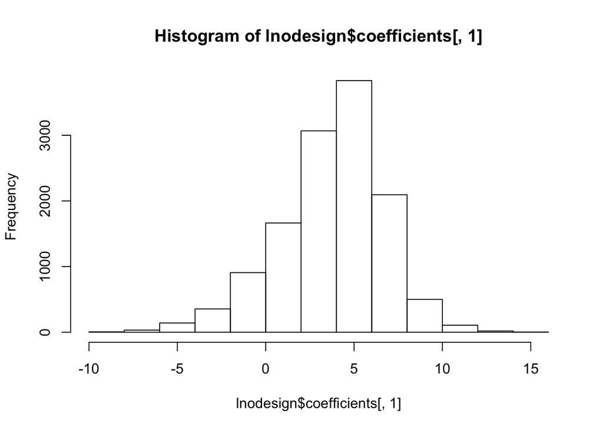

```r
hist(lnodesign$coefficients[,1])
```

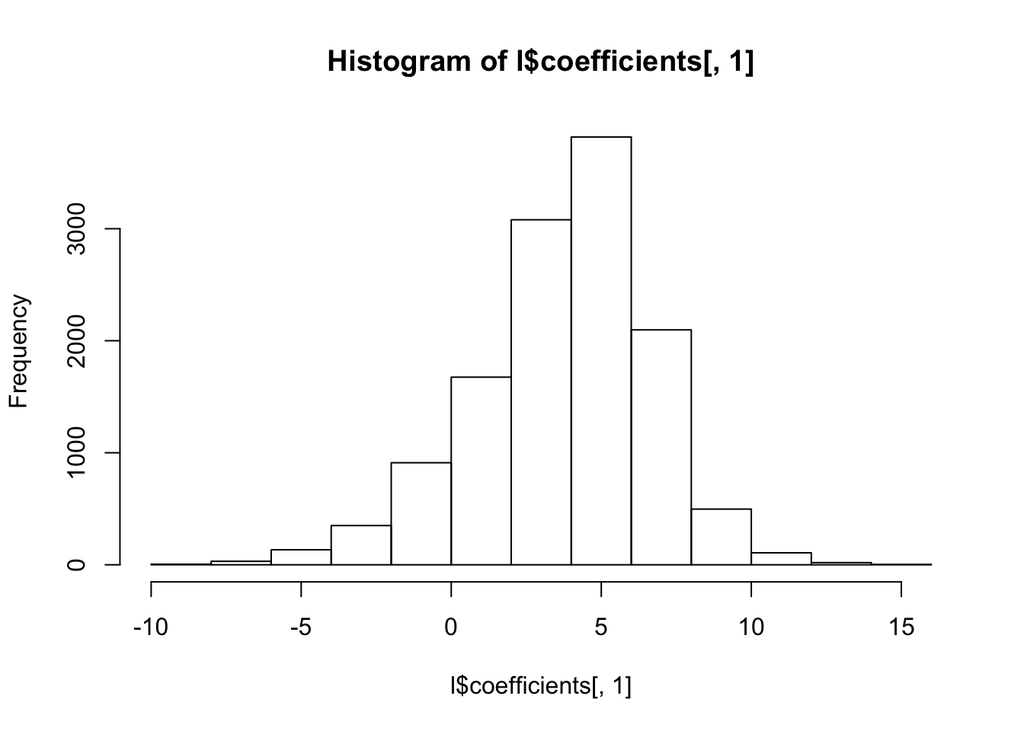

```r
hist(l$coefficients[,1])
```

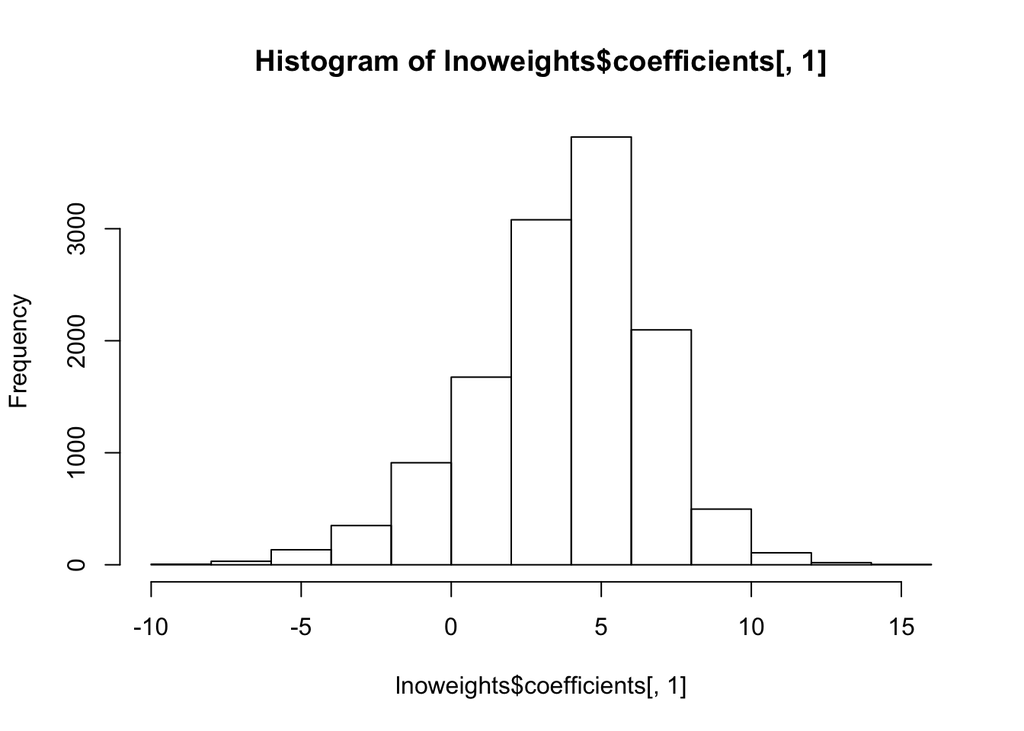

```r
hist(lnoweights$coefficients[,1])
```

What we really want are the average log2CPM (corrected for batch and extraction) that include $\mu_{j}$, and so extracting the covariate from a model that includes extraction and rin as covariates without an intercept will lose $\mu_{j}$ for the gene. So we want to use the batch corrected (i.e., table s1) as our dependent variable. However, then it it adhoc to use weights that were generated on raw counts or raw counts without a design matrix. As you can see, the use of weights doesn’t really make a big difference and seems unprincipled (e.g., using the log2corrected data as y with the voom object as inputs for weights). John advised me to use the log2 corrected data so that I could use just one covariate (group status) and not use weights at all.